# 공간 데이터 분석 in R

Sung

2017-12-10

### **공간 데이터**

공간 데이터(spatial data)는 지형지물(지구상의 자연적,인공적 형상)의 지리적 위치와 특성에 관한 정보. 지리정보시스템에서 사용하는 데이터를 말함

- 지리 좌표계(Geographic coordinate system): 지구 및 천체에 지점을 나타내기 위한 위/경도 좌표계 ([링크](https://ko.wikipedia.org/w/index.php?oldid=19775468))
- 데이터 형태: 폴리곤 형태로 `.shp`파일로 제공 되고, 한국 전국의 시도, 시군구, 읍면동, 리 경계 데이터를 제공 [행안부_주소](https://www.juso.go.kr/addrlink/devLayerRequestWrite.do), [지오서비스](http://www.gisdeveloper.co.kr/?p=2332))
- 분석 도구: `ArcGIS`, `QGIS`, `R` 등이 있고 `QGIS`와 `R`은 오픈소스임

### **주요 좌표계**

좌표계는 좌표계 코드(EPSG)와 문법으로 표현 가능 ([추가정보](https://mgimond.github.io/Spatial/coordinate-systems-in-r.html))

- WGS84 경위도: GPS가 사용하는 좌표계
  - EPSG:4326, EPSG:4166 (Korean 1995)
  - +proj=longlat +ellps=WGS84 +datum=WGS84 +no_defs
- UTM-K(GRS-80) 좌표계
  - EPSG:5179
  - +proj=tmerc +lat_0=38 +lon_0=127.5 +k=0.9996 +x_0=1000000 +y_0=2000000 +ellps=GRS80 +units=m +no_defs
- UTM-K (Bessel): 새주소지도에서 사용 중
  - EPSG:5178
  - +proj=tmerc +lat_0=38 +lon_0=127.5 +k=0.9996 +x_0=1000000 +y_0=2000000 +ellps=bessel +units=m +no_defs +towgs84=-115.80,474.99,674.11,1.16,-2.31,-1.63,6.43
- 그외 좌표계: http://www.osgeo.kr/17,
- 참고: https://mrchypark.wordpress.com/2014/10/23/%ec%a2%8c%ed%91%9c-%ec%a0%95%eb%b3%b4-%eb%b3%80%ed%99%98/

### **위치 데이터 불러오기**

- 각 변수의 타입에 맞게 데이터 불러오기
  - `st_crs(shp_data)$proj4string`를 통해 좌표계를 알 수 있음
  - 국가에서 제공하는 파일의 인코딩은 `euc-kr`이라서 인코딩을 명시해야 함

  ```r
  # load package
  library(tidyverse)
  library(sf)

  # 시도 shp
  sido <- st_read("../data/CTPRVN_201703/TL_SCCO_CTPRVN.shp", stringsAsFactors = F, quiet = T, options = "encoding=euc-kr")
  glimpse(sido)
  ##> Observations: 17
  ##> Variables: 4
  ##> $ CTPRVN_CD  <chr> "11", "26", "27", "28", "29", "30", "31", "36", "41...
  ##> $ CTP_ENG_NM <chr> "Seoul", "Busan", "Daegu", "Incheon", "Gwangju", "D...
  ##> $ CTP_KOR_NM <chr> "서울특별시", "부산광역시", "대구광역시", "인천광역시", "광주광역시", "대전광역시...
  ##> $ geometry   <simple_feature> MULTIPOLYGON (((965666.5034..., MULTIPOL...
  st_crs(sido)$proj4string
  ##> [1] "+proj=tmerc +lat_0=38 +lon_0=127.5 +k=0.9996 +x_0=1000000 +y_0=2000000 +ellps=GRS80 +units=m +no_defs"
  ```

- shp 파일에서 지도 그리기

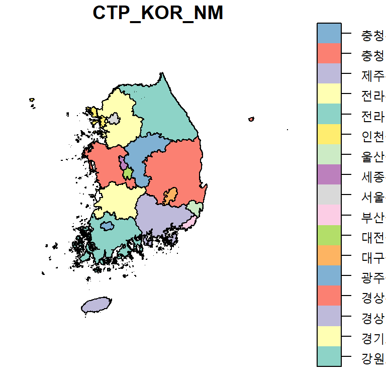

  ```r
  plot(sido[3])
  ```

### **공간 결합**

- 데이터의 위치가 동일한 경우를 매핑하여 데이터 속성을 결합하는 것으로 `sql`에서 `join`을 할 때 사용하는 매핑컬럼을 좌표로 하는 것과 비슷함
  - 아래 결과에서 `point_sf`에 시도 컬럼(`CTP_KOR_NM`)이 추가된 것을 볼 수 있다.

  ```r
  # 임의의 위치를 지정
  df <- data.frame(id = c("a", "b"),
                   lon = c(981731, 945989),
                   lat = c(1932086, 1942347))

  # 데이터프레임에 좌표로 변환
  point_sf <- st_as_sf(df, coords = c("lon", "lat"), crs = st_crs(sido)$proj4string)
  point_sf
  ##> Simple feature collection with 2 features and 1 field
  ##> geometry type:  POINT
  ##> dimension:      XY
  ##> bbox:           xmin: 945989 ymin: 1932086 xmax: 981731 ymax: 1942347
  ##> epsg (SRID):    NA
  ##> proj4string:    +proj=tmerc +lat_0=38 +lon_0=127.5 +k=0.9996 +x_0=1000000 +y_0=2000000 +ellps=GRS80 +units=m +no_defs
  ##>   id               geometry
  ##> 1  a POINT (981731 1932086)
  ##> 2  b POINT (945989 1942347)

  # 시도 join
  point_sf <- st_join(point_sf, sido[, c(3, 4)])

  glimpse(point_sf)
  ##> Observations: 2
  ##> Variables: 3
  ##> $ id         <fctr> a, b
  ##> $ CTP_KOR_NM <chr> "경기도", "서울특별시"
  ##> $ geometry   <simple_feature> POINT (981731 1932086), POINT (945989 19...
  ```

  - 지도에서 좌표 확인

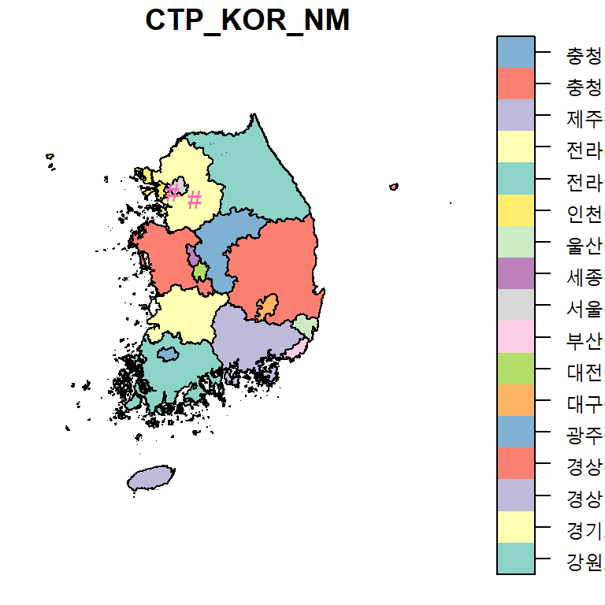

  ```r
  plot(sido[3])
  plot(point_sf$geometry, add = T, pch = '#', col = 'hotpink')
  ```

  ```r
  library(ggmap)

  # 좌표 변경
  point_sf_wgs84 <- st_transform(point_sf, crs = "+proj=longlat +ellps=WGS84 +datum=WGS84 +no_defs")

### 참고

- 참고 사이트
  - http://strimas.com/r/tidy-sf/
  - https://cran.r-project.org/web/packages/sf/vignettes/sf1.html
- 온라인 서적
  - https://bookdown.org/robinlovelace/geocompr/spatial-data-operations.html